# Poker Rule Induction

Jagdeep S. Sihota

The intent of this project is to learn poker rules by applying following 5 five learning algorithms:

- Decision trees with some form of pruning
- Neural networks
- Boosting
- Support Vector Machines
- k-nearest neighbors

This dataset is interesting becasue we need to predict the best hand you can play based on the cards you’ve been dealt without hand coding rules. The order of cards is also important, which means there are 480 possible Royal Flush hands instead of just four. Identify those, and the other 311,875,200 possible hands correctly. Pretend you never played the game before, are given a history of thousands of games, and are asked to come up with the rules. It is potentially difficult to discover rules that can correctly classify poker hands. Algorithm will need to find rules that are general enough to be broadly useful, without being so broad that they end up being occasionally wrong.

# Data

Each record in this dataset consists of five playing cards and an attribute representing the poker hand. You are provided with 25,010 poker hands in train.csv and 1,000,000 in test.csv. Each hand consists of five cards with a given suit and rank, drawn from a standard deck of 52. Suits and ranks are represented as ordinal categories:

Each row in the training set has the accompanying class label for the poker hand it comprises. The hands are omitted from the test set and must be predicted by participants. Hands are classified into the following ordinal categories:

Attribute Information:

1. S1 “Suit of card #1” Ordinal (1-4) representing {Hearts, Spades, Diamonds, Clubs}
2. C1 “Rank of card #1” Numerical (1-13) representing (Ace, 2, 3, … , Queen, King)
3. S2 “Suit of card #2” Ordinal (1-4) representing {Hearts, Spades, Diamonds, Clubs}
4. C2 “Rank of card #2” Numerical (1-13) representing (Ace, 2, 3, … , Queen, King)
5. S3 “Suit of card #3” Ordinal (1-4) representing {Hearts, Spades, Diamonds, Clubs}
6. C3 “Rank of card #3” Numerical (1-13) representing (Ace, 2, 3, … , Queen, King)
7. S4 “Suit of card #4” Ordinal (1-4) representing {Hearts, Spades, Diamonds, Clubs}
8. C4 “Rank of card #4” Numerical (1-13) representing (Ace, 2, 3, … , Queen, King)
9. S5 “Suit of card #5” Ordinal (1-4) representing {Hearts, Spades, Diamonds, Clubs}
10. C5 “Rank of card 5” Numerical (1-13) representing (Ace, 2, 3, … , Queen, King)
11. CLASS “Poker Hand” Ordinal (0-9)

Class Information:

- 0: Nothing in hand; not a recognized poker hand
- 1: One pair; one pair of equal ranks within five cards
- 2: Two pairs; two pairs of equal ranks within five cards
- 3: Three of a kind; three equal ranks within five cards
- 4: Straight; five cards, sequentially ranked with no gaps
- 5: Flush; five cards with the same suit
- 6: Full house; pair + different rank three of a kind
- 7: Four of a kind; four equal ranks within five cards
- 8: Straight flush; straight + flush
- 9: Royal flush; {Ace, King, Queen, Jack, Ten} + flush

# Decision Trees

## decision tree algorithm

### preference and restriction bias in each of the these algorithms

restriction bias all possible trees preference = inductive bias it pref good split at near the top. it pref correct ones to incoret ones. shorter tree to longer trees

Run decion tree

[figure not shown]

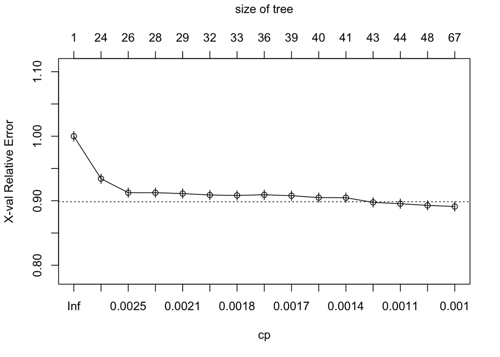

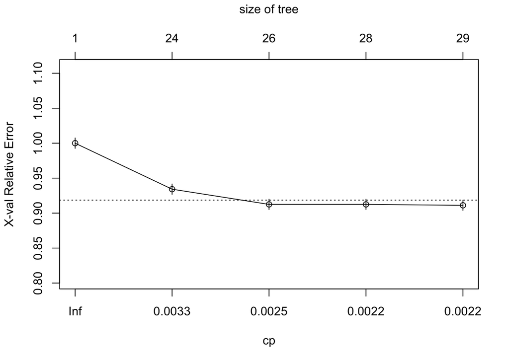

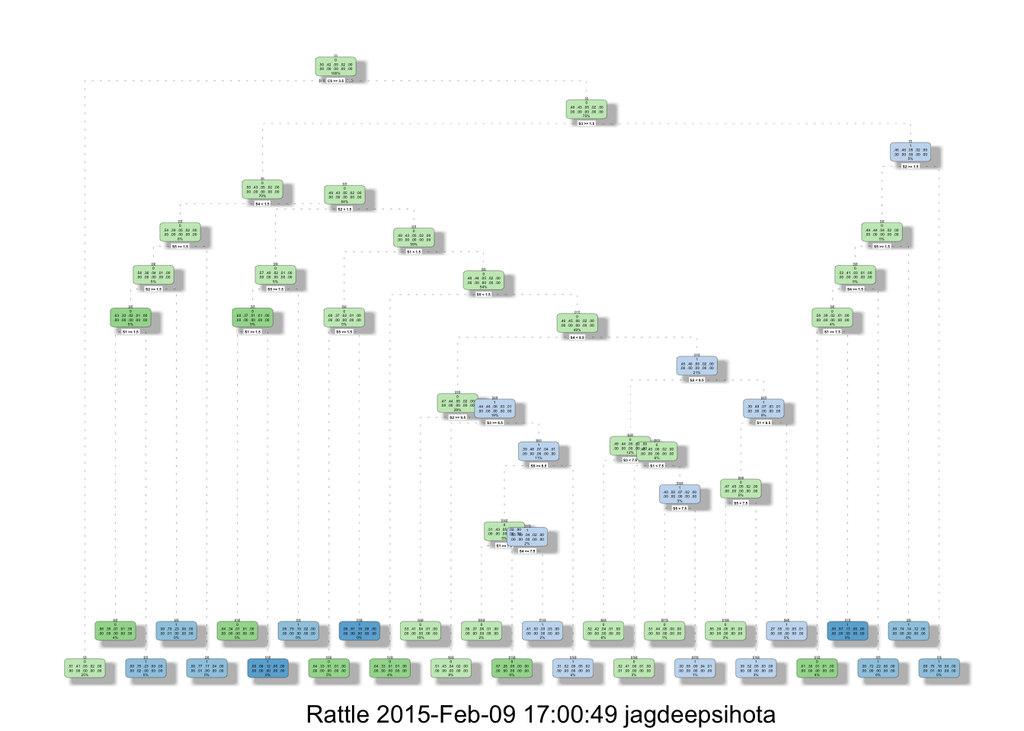

## Generalization Error

### error function when it is a classification problem

## cross-validation and when do you use it? What are the other forms of validation techniques

```
## Confusion Matrix and Statistics
##
##           Reference
## Prediction    0    1    2    3    4    5    6    7    8    9
##          0 3085 2252  202   92   11   10    4    2    0    0
##          1  422  717  129   65   12    2    5    0    0    0
##          2    0    0    0    0    0    0    0    0    0    0
##          3    0    0    0    0    0    0    0    0    0    0
##          4    0    0    0    0    0    0    0    0    0    0
##          5    0    0    0    0    0    0    0    0    0    0
##          6    0    0    0    0    0    0    0    0    0    0
##          7    0    0    0    0    0    0    0    0    0    0
##          8    0    0    0    0    0    0    0    0    0    0
##          9    0    0    0    0    0    0    0    0    0    0
##
## Overall Statistics
##
##                Accuracy : 0.542
##                  95% CI : (0.531, 0.554)
##     No Information Rate : 0.5
##     P-Value [Acc > NIR] : 9.68e-13
##
##                   Kappa : 0.111
##  Mcnemar's Test P-Value : NA
##
## Statistics by Class:
##
##                      Class: 0 Class: 1 Class: 2 Class: 3 Class: 4 Class: 5
## Sensitivity             0.880    0.241   0.0000   0.0000  0.00000  0.00000
## Specificity             0.265    0.843   1.0000   1.0000  1.00000  1.00000
## Pos Pred Value          0.545    0.530      NaN      NaN      NaN      NaN
## Neg Pred Value          0.688    0.602   0.9528   0.9776  0.99672  0.99829
## Prevalence              0.500    0.424   0.0472   0.0224  0.00328  0.00171
## Detection Rate          0.440    0.102   0.0000   0.0000  0.00000  0.00000
## Detection Prevalence    0.807    0.193   0.0000   0.0000  0.00000  0.00000
## Balanced Accuracy       0.573    0.542   0.5000   0.5000  0.50000  0.50000
##                      Class: 6 Class: 7 Class: 8 Class: 9
## Sensitivity           0.00000 0.000000       NA       NA
## Specificity           1.00000 1.000000        1        1
## Pos Pred Value            NaN      NaN       NA       NA
## Neg Pred Value        0.99872 0.999715       NA       NA
## Prevalence            0.00128 0.000285        0        0
## Detection Rate        0.00000 0.000000        0        0
## Detection Prevalence  0.00000 0.000000        0        0
## Balanced Accuracy     0.50000 0.500000       NA       NA
```

```
## Confusion Matrix and Statistics
##
##           Reference
## Prediction      0      1      2      3      4      5      6      7      8
##          0 447891 321305  30425  13215   2176   1803    743     95      6
##          1  53318 101193  17197   7906   1709    193    681    135      6
##          2      0      0      0      0      0      0      0      0      0
##          3      0      0      0      0      0      0      0      0      0
##          4      0      0      0      0      0      0      0      0      0
##          5      0      0      0      0      0      0      0      0      0
##          6      0      0      0      0      0      0      0      0      0
##          7      0      0      0      0      0      0      0      0      0
##          8      0      0      0      0      0      0      0      0      0
##          9      0      0      0      0      0      0      0      0      0
##           Reference
## Prediction      9
##          0      3
##          1      0
##          2      0
##          3      0
##          4      0
##          5      0
##          6      0
##          7      0
##          8      0
##          9      0
##
## Overall Statistics
##
##                Accuracy : 0.549
##                  95% CI : (0.548, 0.55)
##     No Information Rate : 0.501
##     P-Value [Acc > NIR] : <2e-16
##
##                   Kappa : NA
##  Mcnemar's Test P-Value : NA
##
## Statistics by Class:
##
##                      Class: 0 Class: 1 Class: 2 Class: 3 Class: 4 Class: 5
## Sensitivity             0.894    0.240   0.0000   0.0000  0.00000    0.000
## Specificity             0.259    0.859   1.0000   1.0000  1.00000    1.000
## Pos Pred Value          0.548    0.555      NaN      NaN      NaN      NaN
## Neg Pred Value          0.708    0.607   0.9524   0.9789  0.99611    0.998
## Prevalence              0.501    0.422   0.0476   0.0211  0.00388    0.002
## Detection Rate          0.448    0.101   0.0000   0.0000  0.00000    0.000
## Detection Prevalence    0.818    0.182   0.0000   0.0000  0.00000    0.000
## Balanced Accuracy       0.576    0.550   0.5000   0.5000  0.50000    0.500
##                      Class: 6 Class: 7 Class: 8 Class: 9
## Sensitivity           0.00000  0.00000  0.0e+00    0e+00
## Specificity           1.00000  1.00000  1.0e+00    1e+00
## Pos Pred Value            NaN      NaN      NaN      NaN
## Neg Pred Value        0.99858  0.99977  1.0e+00    1e+00
## Prevalence            0.00142  0.00023  1.2e-05    3e-06
## Detection Rate        0.00000  0.00000  0.0e+00    0e+00
## Detection Prevalence  0.00000  0.00000  0.0e+00    0e+00
## Balanced Accuracy     0.50000  0.50000  5.0e-01    5e-01
```

# Neural Networks

## algorithm

### bias-variance tradeoff

### preference and restriction bias in each of the these algorithms

One of the most serious problems that arises in connectionist learning by neural networks is overfitting of the provided training examples. This means that the learned function fits very closely the training data however it does not generalise well, that is it can not model sufficiently well unseen data from the same task.A neural network that fits closely the provided training examples has a low bias but a high variance. If we reduce the network variance this will lead to a decrease in the level of fitting the data.When using neural networks, small neural networks are more prone to under-fitting and big neural networks are prone to over-fitting. Cross-validation of network size is a way to choose alternatives.

## Generalization Error

### error function when it is a classification problem

[output not shown]

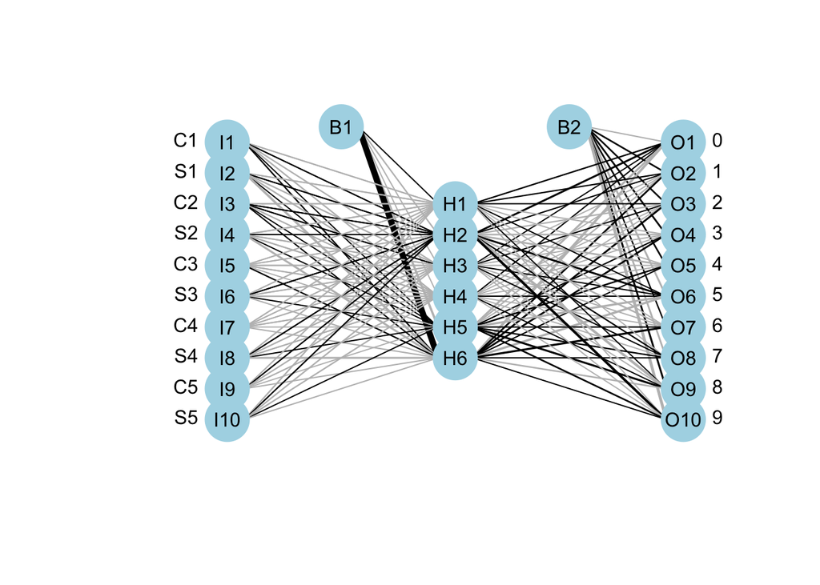

## cross-validation and when do you use it? What are the other forms of validation techniques

```
##             pred
## valid_labels    0    1    2
##            0 2904  603    0
##            1 2126  843    0
##            2  197  133    1
##            3   70   86    1
##            4    8   15    0
##            5   11    1    0
##            6    4    5    0
##            7    1    1    0
##            8    0    0    0
##            9    0    0    0
```

```
##           pred
## testlabels      0      1      2
##          0 420427  80782      0
##          1 297077 125418      3
##          2  29577  17981     64
##          3  10995  10088     38
##          4   1331   2554      0
##          5   1702    294      0
##          6    697    700     27
##          7     82    138     10
##          8      4      8      0
##          9      0      3      0
```